# Fast Style Transfer

> *Style transfer allows you to take famous paintings, and recreate your own images in their styles!*

Neural Style Transfer algorithms make use of deep neural networks to perform the image transformation, such as creating artificial artwork from photographs, by transferring the style of famous paintings to photographs.

This fun project from the Udacity Deep Learning Nanodegree uses the fast-style-transfer GitHub repo by Logan Lengstrom, Either use `git` to clone the repository, or you can download the whole thing as a Zip archive and extract it.

I am going to use it to style the photograph of the lovely ちぃちゃん in the style of different artists.

To access the files easily from one place, I first forked the original repo, then added my image files and the two checkpoint files, Rain Princess and Wave to that repo.

The checkpoints were trained on the following paintings:

- Rain Princesss, by Leonid Afremov
- The Great Wave off Kanagawa, by Hokusai

The easiest way to install all the packages needed to run this code is with Anaconda. You need to install Python 3, Tensorflow, Pillow, and SciPy, and moviepy.

```python
# Install Anaconda
!wget -c https://repo.continuum.io/archive/Anaconda3-5.1.0-Linux-x86_64.sh
!chmod +x Anaconda3-5.1.0-Linux-x86_64.sh
!bash ./Anaconda3-5.1.0-Linux-x86_64.sh -b -f -p /usr/local
```

[output not shown]

[output cut: 206 more lines]

[output not shown]

This set of instructions creates a new environment with Python 3. This environment will hold all the necessary packages. The next line enters the environment. Then, we install TensorFlow, SciPy, Pillow, and moviepy. Last line installs ffmpeg, an application for converting images and videos.

```python
!conda create -n style-transfer python=3
!activate style-transfer
!conda install tensorflow scipy pillow
!pip install moviepy
!python -c "import imageio; imageio.plugins.ffmpeg.download()"
```

[output not shown]

[output cut: 167 more lines]

[output not shown]

```python
# imageio.ffmpeg.download() has been deprecated.
pip install imageio-ffmpeg
```

I am carrying out this project in **Google Colab**. I now want to access the **content** folder in my Colab project files.

```python
! pwd
```

```
/content
```

Downloading and extracting fast-style-transfer.

```python
!git clone https://github.com/SabrinaPalis/fast-style-transfer.git
```

```
Cloning into 'fast-style-transfer'...
remote: Enumerating objects: 2, done.
remote: Counting objects: 100% (2/2), done.
remote: Compressing objects: 100% (2/2), done.
remote: Total 207 (delta 0), reused 0 (delta 0), pack-reused 205
Receiving objects: 100% (207/207), 46.61 MiB | 44.64 MiB/s, done.
Resolving deltas: 100% (91/91), done.
```

Navigating to the folder.

```python
cd /content/fast-style-transfer
```

```
/content/fast-style-transfer
```

Applying the Rain Princess transfer style to the lovely picture akita.jpg.

```python
! python evaluate.py --checkpoint ./rain-princess.ckpt \
  --in-path ./akita.jpg \
  --out-path ./output_image.jpg
```

Displaying the image.

Now this is one hot Leonid Afremov Dog Princess!

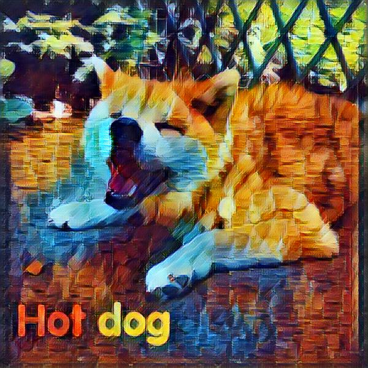

```python
from IPython.display import Image
Image('output_image.jpg')
```

Applying the Wave transfer style to the lovely picture akitab.jpg.

```python
! python evaluate.py --checkpoint ./wave.ckpt \
  --in-path ./akitab.jpg \
  --out-path ./output_image.jpg
```

Displaying the image.

[figure not shown]

```python
from IPython.display import Image
Image('output_image.jpg')
```

ちぃちゃん looks like she's just popped out of a Manga!